# Predicting Genetic Disorders

Emma Oo[^1], Sindhu Bhattarai[^2], Dave Friesen[^3]

06/27/2022

### Data Load and Validation

```r
gd_df = read.csv(file="/Users/sakshyamdahal/Desktop/MS_Data_Science/Applied Predictive Modeling/Final_project/train_genetic_disorders.csv", header= TRUE)
dim(gd_df)
```

```
[1] 22083    45
```

###### Data Structure Review

```r
# Summarize base dataset and [optionally] sample rows
str(gd_df)
```

```
'data.frame':   22083 obs. of  45 variables:
 $ Patient.Id                                      : chr  "PID0x6418" "PID0x25d5" "PID0x4a82" "PID0x4ac8" ...
 $ Patient.Age                                     : int  2 4 6 12 11 14 3 3 11 4 ...
 $ Genes.in.mother.s.side                          : chr  "Yes" "Yes" "Yes" "Yes" ...
 $ Inherited.from.father                           : chr  "No" "Yes" "No" "No" ...
 $ Maternal.gene                                   : chr  "Yes" "No" "No" "Yes" ...
 $ Paternal.gene                                   : chr  "No" "No" "No" "No" ...
 $ Blood.cell.count..mcL.                          : num  4.76 4.91 4.89 4.71 4.72 ...
 $ Patient.First.Name                              : chr  "Richard" "Mike" "Kimberly" "Jeffery" ...
 $ Family.Name                                     : chr  "" "" "" "Hoelscher" ...
 $ Father.s.name                                   : chr  "Larre" "Brycen" "Nashon" "Aayaan" ...
 $ Mother.s.age                                    : int  NA NA 41 21 32 NA NA 40 45 44 ...
 $ Father.s.age                                    : int  NA 23 22 NA NA NA 63 NA 44 42 ...
 $ Institute.Name                                  : chr  "Boston Specialty & Rehabilitation Hospital" "St. Margaret's Hospital For Women" "" "" ...
 $ Location.of.Institute                           : chr  "55 FRUIT ST\nCENTRAL, MA 02114\n(42.36247485742686, -71.06924724545246)" "1515 COMMONWEALTH AV\nALLSTON/BRIGHTON, MA 02135\n(42.34665771451756, -71.14136122385321)" "-" "55 FRUIT ST\nCENTRAL, MA 02114\n(42.36247485742686, -71.06924724545246)…
```

[output cut: 31 more lines]

```r
#head(gd_df, 3)
```

###### Initial feature reduction

Uninformative Feature Reduced

```r
# Define n/a columns and subset dataframe; Note retaining "some" informational variables like "Institute.Name" for
#   possible descriptive analytic purposes
drop_cols <- c("Patient.Id",
               "Patient.First.Name",
               "Family.Name",
               "Father.s.name",
               "Institute.Name",
               "Location.of.Institute",
               "Status",
               "Test.1",
               "Test.2",
               "Test.3",
               "Test.4",
               "Test.5",
               "Parental.consent",
               "Place.of.birth")
gd_df <- gd_df[ , !(names(gd_df) %in% drop_cols)]

dim(gd_df)
```

```
[1] 22083    31
```

###### Class Target and Label Review

```r
# Check for missing labels; set aside where missing
missing_target <- which(is.na(gd_df$Disorder.Subclass) | (gd_df$Disorder.Subclass == ""))
cat("Rows pre-subset for missing labels: ", format(nrow(gd_df), format = "d", big.mark = ","), sep = "")
```

```
Rows pre-subset for missing labels: 22,083
```

```r
gd_hold_df <- gd_df[missing_target, ]
gd_df <- gd_df[-missing_target, ]

cat("Deleted rows with missing labels: ", format(nrow(gd_hold_df), format = "d", big.mark = ","), sep = "")
```

```
Deleted rows with missing labels: 3,140
```

```r
cat(" Remaining rows (labeled): ", format(nrow(gd_df), format = "d", big.mark = ","), sep = "")
```

```
 Remaining rows (labeled): 18,943
```

```r
# Show frequency distribution for [prospective] target class(es)
show_frequency <- function(desc, c) {
  t <- as.data.frame(prop.table(table(c)))
  colnames(t) <- c("Class", "Frequency")
  cat(desc, "\n"); print(t[order(-t$Freq, t$Class), 1:2], row.names = FALSE)
}
show_frequency("Pre-Split Frequency Distribution", gd_df$Disorder.Subclass)
```

```
Pre-Split Frequency Distribution
                               Class Frequency
                      Leigh syndrome     0.258
              Mitochondrial myopathy     0.222
                     Cystic fibrosis     0.173
                           Tay-Sachs     0.142
                            Diabetes     0.092
                     Hemochromatosis     0.068
 Leber's hereditary optic neuropathy     0.032
                         Alzheimer's     0.008
                              Cancer     0.005
```

```r
# Move the target class to "top" of dataframe so column removals don't impact
gd_df <- gd_df[ , c(ncol(gd_df), 1:(ncol(gd_df) - 1))]
target_col = 1


gd_df$Disorder.Subclass <- gsub("'", "", gd_df$Disorder.Subclass, fixed = TRUE)
gd_df$Disorder.Subclass <- gsub(" ", ".", gd_df$Disorder.Subclass, fixed = TRUE)
gd_df$Disorder.Subclass <- gsub("-", ".", gd_df$Disorder.Subclass, fixed = TRUE)
```

### Data Partition

###### Split the dataframe as per target class (Disorder.Subclass vector)

**There is certain class imbalance problem. We will split the data frame using createDataPartition function using target class(Disorder.Subclass) which helps us to get even balance of all classes in both train and test data**

```r
# Split data 80/20 train/test, using caret's inherent stratified split to compensate for class imbalance
set.seed(1)
train_index <- createDataPartition(gd_df$Disorder.Subclass, times = 1, p = 0.80, list = FALSE)
train_df <- gd_df[train_index, ]
test_df <- gd_df[-train_index, ]
show_frequency("Post-Split Frequency Distribution (Train)", train_df$Disorder.Subclass)
```

```
Post-Split Frequency Distribution (Train)
                              Class Frequency
                     Leigh.syndrome     0.258
             Mitochondrial.myopathy     0.222
                    Cystic.fibrosis     0.173
                          Tay.Sachs     0.142
                           Diabetes     0.092
                    Hemochromatosis     0.068
 Lebers.hereditary.optic.neuropathy     0.032
                         Alzheimers     0.008
                             Cancer     0.005
```

### Handling Missing Values

###### Checking Mislabeled Data and Missing Values

```r
library(dplyr)
library(questionr)

#lapply(train_df, unique)

# changing values which are labeled as not available and no record to a readable format 'NA'
train_df[ train_df == "Not available"] <- NA
test_df[ test_df == "Not available"] <- NA

train_df[train_df == "No record"] <- NA
test_df[test_df == "No record"] <- NA

#changing None to "No" (there is None in one vector "Autopsy.shows.birth.defect..if.applicable." where none birth defects resemble no class)
train_df[train_df == "None"] <- "No"
test_df[test_df == "None"] <- "No"


freq.na(train_df)
```

```
                                                 missing  %
Birth.asphyxia                                      6908 46
Mother.s.age                                        3947 26
Father.s.age                                        3853 25
Symptom.2                                           1457 10
Symptom.5                                           1451 10
White.Blood.cell.count..thousand.per.microliter.    1437  9
No..of.previous.abortion                            1418  9
Symptom.1                                           1410  9
Symptom.4                                           1382  9
Symptom.3                                           1363  9
Patient.Age                                          960  6
Disorder.Subclass                                      0  0
Genes.in.mother.s.side                                 0  0
Inherited.from.father                                  0  0
Maternal.gene                                          0  0
Paternal.gene                                          0  0
Blood.cell.count..mcL.                                 0  0
Respiratory.Rate..breaths.min.                         0  0
Heart.Rate..rates.min                                  0  0
Follow.up                                              0  0
Gender                                                 0  0
Autopsy.shows.birth.defect..if.applicable.             0  0
Folic.acid.details..peri.conceptional.                 0  0
H.O.serious.maternal.illness                           0  0
H.O.radiation.exposure..x.ray.                         0  0
H.O.substance.abuse                                    0  0
Assisted.conception.IVF.ART                            0  0
History.of.anomalies.in.previous.pregnancies           0  0
Birth.defects                                          0  0
Blood.test.result                                      0  0
Genetic.Disorder                                       0  0
```

```r
sum(is.na(train_df))
```

```
[1] 25586
```

**Note:We will be removing “Birth.asphyxia” vector from our data as there is 46% missing data. Here, the imputation might create bias model.Further,we will be performing median imputation for integer vectors. For categorical vectors we will be encoding the missing value as “not provided”. Here we can also do mode imputation but we would like to learn if the missing value has any relation with target. For numeric vectors we will be applying mean imputation.**

```r
train_df <- subset(train_df, select = -c(Birth.asphyxia))
test_df <- subset(test_df, select = -c(Birth.asphyxia))

# Impute basic integer values with medians

medianf <- function(x) {
 result <- median(x, na.rm = TRUE)
 if (is.integer(x))
   result <- as.integer(result)
 return(result)
}
median_cols = c("Patient.Age", "Mother.s.age", "Father.s.age", "No..of.previous.abortion")
for (n in median_cols) {
  train_df[n][is.na(train_df[n])] <- apply(train_df[n], 2, medianf)
  test_df[n][is.na(test_df[n])] <- apply(test_df[n], 2, medianf)
}

# Impute categorical blanks with common "notprovided"; note we could also impute these with categorical mode,
#   or most frequent categorical value of each column using the cmode() function below
cols_tofill <- c("Inherited.from.father",
                 "Maternal.gene",
                 "Respiratory.Rate..breaths.min.",
                 "Heart.Rate..rates.min",
                 "Follow.up",
                 "Gender",
                 "Autopsy.shows.birth.defect..if.applicable.",
                 "Folic.acid.details..peri.conceptional.",
                 "H.O.serious.maternal.illness",
                 "H.O.radiation.exposure..x.ray.",
                 "H.O.substance.abuse",
                 "Assisted.conception.IVF.ART",
                 "History.of.anomalies.in.previous.pregnancies",
                 "Birth.defects",
                 "Blood.test.result",
                 "Genetic.Disorder")
train_df[cols_tofill][train_df[cols_tofill] == ""] <- "notprovided"
test_df[cols_tofill][test_df[cols_tofill] == ""] <- "notprovided"

train_df[cols_tofill][train_df[cols_tofill] == "-"] <- "notprovided"
test_df[cols_tofill][test_df[cols_tofill] == "-"] <- "notprovided"


cmode <- function(x) {
  uniqx <- unique(na.omit(x))
  uniqx[which.max(tabulate(match(x, uniqx)))]
}

# Impute what appear to be masked "flag" columns iwth placeholder -1 values. . .
flag_cols <- c("Symptom.1", "Symptom.2", "Symptom.3", "Symptom.4", "Symptom.5")
train_df[flag_cols][is.na(train_df[flag_cols])] <- as.integer(-1)
test_df[flag_cols][is.na(test_df[flag_cols])] <- as.integer(-1)

# Impute mean for one numeric column
train_df$White.Blood.cell.count..thousand.per.microliter.[is.na(train_df$White.Blood.cell.count..thousand.per.microliter.)] <-
  mean(train_df$White.Blood.cell.count..thousand.per.microliter., na.rm = TRUE)
test_df$White.Blood.cell.count..thousand.per.microliter.[is.na(test_df$White.Blood.cell.count..thousand.per.microliter.)] <-
  mean(test_df$White.Blood.cell.count..thousand.per.microliter., na.rm = TRUE)
```

```r
#lapply(train_df, unique)
```

### Pre-processing

###### Feature Pre-processing (including variable types/formats, names)

```r
# preprocess variables
factor_cols <- c("Genes.in.mother.s.side",
                 "Inherited.from.father",
                 "Maternal.gene",
                 "Paternal.gene",
                 "Respiratory.Rate..breaths.min.",
                 "Heart.Rate..rates.min",
                 "Follow.up",
                 "Gender",
                 "Autopsy.shows.birth.defect..if.applicable.",
                 "Folic.acid.details..peri.conceptional.",
                 "H.O.serious.maternal.illness",
                 "H.O.radiation.exposure..x.ray.",
                 "H.O.substance.abuse",
                 "Assisted.conception.IVF.ART",
                 "History.of.anomalies.in.previous.pregnancies",
                 "Birth.defects",
                 "Blood.test.result",
                 "Disorder.Subclass",
                 "Genetic.Disorder")
train_df[factor_cols] <- lapply(train_df[factor_cols], factor)
test_df[factor_cols] <- lapply(test_df[factor_cols], factor)
# Note factors can be changed in dummy variables for better performances while in modeling.

# Generate updated summary of base dataset
str(train_df)
```

```
'data.frame':   15158 obs. of  30 variables:
 $ Disorder.Subclass                               : Factor w/ 9 levels "Alzheimers","Cancer",..: 6 3 4 7 2 9 9 7 4 3 ...
 $ Patient.Age                                     : int  2 4 6 12 11 3 3 11 4 7 ...
 $ Genes.in.mother.s.side                          : Factor w/ 2 levels "No","Yes": 2 2 2 2 2 2 1 1 1 1 ...
 $ Inherited.from.father                           : Factor w/ 3 levels "No","notprovided",..: 1 3 1 1 1 1 1 1 3 1 ...
 $ Maternal.gene                                   : Factor w/ 3 levels "No","notprovided",..: 3 1 1 3 2 3 3 3 3 1 ...
 $ Paternal.gene                                   : Factor w/ 2 levels "No","Yes": 1 1 1 1 2 2 2 1 2 2 ...
 $ Blood.cell.count..mcL.                          : num  4.76 4.91 4.89 4.71 4.72 ...
 $ Mother.s.age                                    : int  35 35 41 21 32 35 40 45 44 35 ...
 $ Father.s.age                                    : int  42 23 22 42 42 63 42 44 42 42 ...
 $ Respiratory.Rate..breaths.min.                  : Factor w/ 3 levels "Normal (30-60)",..: 1 3 1 3 3 1 3 3 3 1 ...
 $ Heart.Rate..rates.min                           : Factor w/ 3 levels "Normal","notprovided",..: 1 1 3 1 3 2 1 3 3 3 ...
 $ Follow.up                                       : Factor w/ 3 levels "High","Low","notprovided": 1 1 2 1 2 2 2 2 2 2 ...
 $ Gender                                          : Factor w/ 4 levels "Ambiguous","Female",..: 4 4 4 3 3 3 4 3 3 3 ...
 $ Autopsy.shows.birth.defect..if.applicable.      : Factor w/ 4 levels "No","Not applicable",..: 2 1 2 1 2 2 2 2 2 1 ...
```

[output cut: 16 more lines]

###### Collinearity and Dependencies

```r
# Calculate Cramer's V "measure of association" between nominal factor variables (uses Chi-square statistic)
cscorr <- PairApply(train_df[ , sapply(train_df, is.factor)], CramerV, symmetric = TRUE)

# Shorten variable names for ease of reviewing output matrix
rn <- rownames(cscorr)
for (n in 1:length(rownames(cscorr))) {
  rn[n] <- paste(rownames(cscorr)[n], " (", AscToChar(64 + n), ")", sep = "")
  rownames(cscorr)[n] <- paste(AscToChar(64 + n))
}
for (n in 1:length(colnames(cscorr)))
  colnames(cscorr)[n] <- paste(AscToChar(64 + n))

# Show master list of variable names along with output ("correlation") matrix
cat(rn, sep = "\n")
```

```
Disorder.Subclass (A)
Genes.in.mother.s.side (B)
Inherited.from.father (C)
Maternal.gene (D)
Paternal.gene (E)
Respiratory.Rate..breaths.min. (F)
Heart.Rate..rates.min (G)
Follow.up (H)
Gender (I)
Autopsy.shows.birth.defect..if.applicable. (J)
Folic.acid.details..peri.conceptional. (K)
H.O.serious.maternal.illness (L)
H.O.radiation.exposure..x.ray. (M)
H.O.substance.abuse (N)
Assisted.conception.IVF.ART (O)
History.of.anomalies.in.previous.pregnancies (P)
Birth.defects (Q)
Blood.test.result (R)
Genetic.Disorder (S)
```

```r
cscorr
```

```
     A     B     C     D     E     F     G    H    I     J     K     L     M     N     O     P     Q    R    S
A 1.00 0.198 0.131 0.123 0.168 0.019 0.026 0.02 0.02 0.018 0.020 0.019 0.022 0.018 0.019 0.026 0.025 0.03 0.78
B 0.20 1.000 0.005 0.097 0.012 0.005 0.005 0.01 0.01 0.009 0.013 0.009 0.015 0.008 0.003 0.017 0.008 0.01 0.08
C 0.13 0.005 1.000 0.013 0.093 0.018 0.020 0.01 0.02 0.015 0.021 0.013 0.013 0.009 0.013 0.018 0.016 0.02 0.07
D 0.12 0.097 0.013 1.000 0.008 0.048 0.040 0.05 0.05 0.035 0.053 0.048 0.034 0.026 0.055 0.047 0.044 0.05 0.06
E 0.17 0.012 0.093 0.008 1.000 0.003 0.009 0.01 0.01 0.025 0.003 0.001 0.008 0.009 0.003 0.008 0.006 0.02 0.06
F 0.02 0.005 0.018 0.048 0.003 1.000 0.045 0.03 0.05 0.018 0.043 0.028 0.023 0.012 0.035 0.036 0.042 0.04 0.05
G 0.03 0.005 0.020 0.040 0.009 0.045 1.000 0.04 0.05 0.023 0.035 0.029 0.025 0.017 0.055 0.042 0.041 0.05 0.05
H 0.02 0.015 0.012 0.046 0.011 0.029 0.040 1.00 0.04 0.038 0.041 0.043 0.019 0.024 0.043 0.051 0.038 0.05 0.04
I 0.02 0.010 0.023 0.047 0.010 0.054 0.045 0.04 1.00 0.022 0.032 0.051 0.024 0.022 0.035 0.028 0.036 0.04 0.04
J 0.02 0.009 0.015 0.035 0.025 0.018 0.023 0.04 0.02 1.000 0.028 0.019 0.015 0.016 0.016 0.024 0.029 0.03 0.03
K 0.02 0.013 0.021 0.053 0.003 0.043 0.035 0.04 0.03 0.028 1.000 0.020 0.012 0.024 0.028 0.032 0.030 0.04 0.04
L 0.02 0.009 0.013 0.048 0.001 0.028 0.029 0.04 0.05 0.019 0.020 1.000 0.020 0.022 0.043 0.042 0.032 0.04 0.05
M 0.02 0.015 0.013 0.034 0.008 0.023 0.025 0.02 0.02 0.015 0.012 0.020 1.000 0.015 0.024 0.031 0.030 0.03 0.02
N 0.02 0.008 0.009 0.026 0.009 0.012 0.017 0.02 0.02 0.016 0.024 0.022 0.015 1.000 0.017 0.027 0.019 0.02 0.02
O 0.02 0.003 0.013 0.055 0.003 0.035 0.055 0.04 0.03 0.016 0.028 0.043 0.024 0.017 1.000 0.035 0.032 0.03 0.03
P 0.03 0.017 0.018 0.047 0.008 0.036 0.042 0.05 0.03 0.024 0.032 0.042 0.031 0.027 0.035 1.000 0.032 0.04 0.03
Q 0.02 0.008 0.016 0.044 0.006 0.042 0.041 0.04 0.04 0.029 0.030 0.032 0.030 0.019 0.032 0.032 1.000 0.04 0.05
R 0.03 0.013 0.018 0.052 0.016 0.036 0.046 0.05 0.04 0.028 0.042 0.041 0.028 0.024 0.031 0.041 0.044 1.00 0.04
S 0.78 0.082 0.065 0.063 0.064 0.054 0.045 0.04 0.04 0.030 0.035 0.046 0.024 0.023 0.034 0.030 0.053 0.04 1.00
```

### Exploratory Data Analysis(EDA)

```r
dim(train_df)
```

```
[1] 15158    30
```

###### Outlier detection

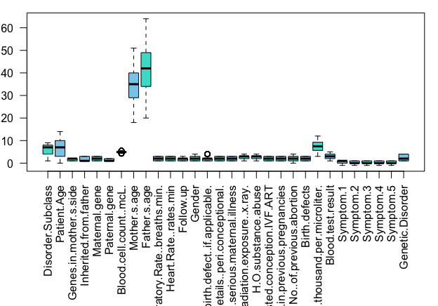

```r
par(mar=c(10,2,1,1))
boxplot(train_df, las=2, col = c("turquoise","skyblue"))
```

###### Frequency distribution

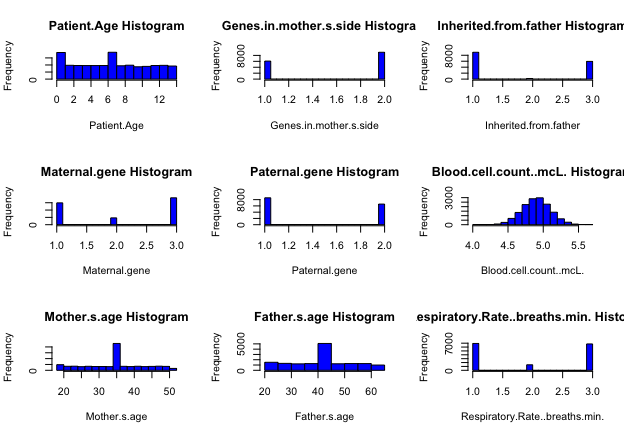

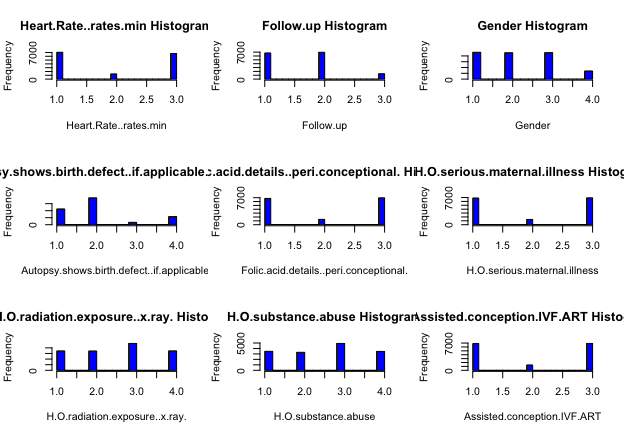

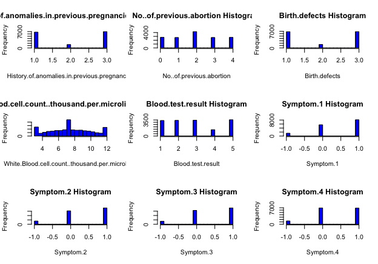

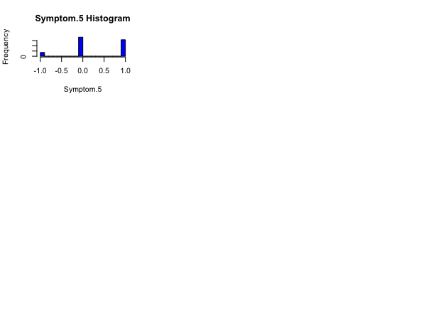

```r
pred_for_hist <- train_df[,2:29]
pred_for_hist <- pred_for_hist %>% mutate_if(is.character, as.numeric)
pred_for_hist <- pred_for_hist %>% mutate_if(is.factor, as.numeric)
par(mfrow = c(3, 3))

for (i in 1:ncol(pred_for_hist)) {
  hist(pred_for_hist[ ,i], xlab = names(pred_for_hist[i]), main = paste(names(pred_for_hist[i]), "Histogram"), col="blue")
}
```

```r
#par(mfrow = c(4, 4))
#for (i in 1:ncol(pred_for_hist)) {
#d <- density(pred_for_hist[,i], na.rm = TRUE)
#plot(d, main = paste(names(pred_for_hist[i]), "Density"))
#polygon(d, col="blue")
#}
```

###### Relation with target based on our hypothesis that the maternal and paternal genes might be cause of transmission of the genetic diorders.

[figure not shown]

```r
library(ggplot2)
#install.packages("patchwork")
#install.packages("cowplot")

library(patchwork)
library(cowplot)
p1 <- ggplot(train_df, aes(x = train_df$Patient.Age, fill = train_df$Disorder.Subclass)) +geom_bar() + theme_classic()+scale_fill_hue(c=60, l=80)
p2 <- ggplot(train_df, aes(x = train_df$Maternal.gene, fill = train_df$Disorder.Subclass)) +geom_bar() +theme_classic()+ scale_fill_hue(c=60, l=80)
p3 <- ggplot(train_df, aes(x = train_df$Paternal.gene, fill = train_df$Disorder.Subclass)) +geom_bar() +theme_classic()+ scale_fill_hue(c=60, l=80)

p1+p2/p3
```

### Modeling

###### Assigning target and Predictors

```r
#test train before dummy
train_x <- train_df[,2:29]
train_y <- train_df[,1]

test_x <- test_df[,2:29]
test_y <- test_df[,1]

dim(train_x)
```

```
[1] 15158    28
```

```r
dim(test_x)
```

```
[1] 3785   28
```

```r
#subsetting numeric columns and character for changing categorical into dummy
library(dplyr)
# Subset numeric columns with dplyr

numeric_pred_train <- select_if(train_x, is.numeric)
numeric_pred_test<- select_if(test_x, is.numeric)

# Subset categorical columns with dplyr
cat_pred_train <- select_if(train_x,is.factor)
cat_pred_test <- select_if(test_x,is.factor)

dim(numeric_pred_train)
```

```
[1] 15158    11
```

```r
dim(numeric_pred_test)
```

```
[1] 3785   11
```

```r
dim(cat_pred_train)
```

```
[1] 15158    17
```

```r
dim(cat_pred_test)
```

```
[1] 3785   17
```

```r
#encode to dummy
library(lattice)
dummies <- dummyVars(~ ., data=cat_pred_train[,1:17])
dummy_cat_df <- predict(dummies, cat_pred_train[,1:17])

dummies_test <- dummyVars(~ ., data=cat_pred_test[,1:17])
dummy_cat_df_test<- predict(dummies, cat_pred_test[,1:17])

#ready to model train test
train_x<- as.data.frame(cbind(numeric_pred_train, dummy_cat_df))
train_y <- as.factor(train_y)

test_x<- as.data.frame(cbind(numeric_pred_test, dummy_cat_df_test))
test_y <- as.factor(test_y)
```

**Setting control function for our multiclass classification**

```r
ctrl <- trainControl(method = "cv",
                     summaryFunction = multiClassSummary,
                     classProbs = TRUE,
                     savePredictions = TRUE)
```

```r
set.seed(476)

#nnetGrid <- expand.grid(size=1:3, decay=c(0,0.1,0.2,0.3,0.4,0.5,1,2))

#nnetFit <- train(x =  train_x,
               # y = train_y,
              #  method = "nnet",
              #  tuneGrid = nnetGrid,
              #  metric = "ROC",
             #   trace = FALSE,
              #  maxit = 2000,
               # trControl = ctrl)
```

```r
#sigmaEst <- kernlab::sigest(as.matrix(train_x))
#svmgrid <- expand.grid(sigma = sigmaEst, C = 2^seq(-4,+4))

#set.seed(476)
#svmRFit <- train(x = train_x ,
               # y = train_y,
               # method = "svmRadial",
               # tuneGrid = svmgrid,
               # metric = "ROC",
                #trControl = ctrl)
```

[^1]: University of San Diego, eoo@sandiego.edu
[^2]: University of San Diego, sbhattarai@sandiego.edu
[^3]: University of San Diego, dfriesen@sandiego.edu